# Big Data in R - IMDB database

Emil Sievänen

2/2/2021

# Introduction

In this demonstration, we will go through some big data manipulation and profiling. We explore the IMDB database that is available at the [IMDB website](https://datasets.imdbws.com/). Just download the three datasets: “title.akas”, “title.basics” and “title.ratings” and you are good to go. We will combine these datasets into one large table with a total size of 1.9 Gb, so it might take some time to load these datasets. The full source code for this notebook is available at [GitHub](https://github.com/eenaveis/imdb-r).

# Data Preparation

We start with loading the three datasets into our program and restrict the data to contain only U.S. movies.

```r
title_akas <- read_tsv("title.akas.tsv", na = c("", "\\N"))

title_basics <- read_tsv("title.basics.tsv", na = c("", "\\N"))

title_ratings <- read_tsv("title.ratings.tsv", na = c("", "\\N"))
```

```r
title_akas <- title_akas %>%
  filter(region == "US") %>%
  rename(tconst = titleId) %>%
  select(tconst, title)

title_basics <- title_basics %>%
  select(tconst, startYear, runtimeMinutes, genres)

title_ratings <- title_ratings %>%
  select(tconst, averageRating)
```

The first dataset “title_akas” contains information about the movie titles. The second dataset “title_basics” contains more detailed data about the individual movies: release year, runtime in minutes and genres. The final dataset “title.ratings” contains the average ratings for each movie.

We join these three tables together with the `left_join` function, which joins two tables together so that all matching rows are combined together and all observations from the first table are returned.

```r
imdb <- title_akas %>%
  left_join(title_basics, by = "tconst") %>%
  left_join(title_ratings, by = "tconst")

imdb
```

```
## # A tibble: 979,823 x 6
##    tconst   title              startYear runtimeMinutes genres     averageRating
##    <chr>    <chr>                  <dbl>          <dbl> <chr>              <dbl>
##  1 tt00000~ Carmencita              1894              1 Documenta~           5.7
##  2 tt00000~ The Clown and His~      1892              5 Animation~           6.1
##  3 tt00000~ Blacksmithing Sce~      1893              1 Comedy,Sh~           6.1
##  4 tt00000~ Blacksmith Scene ~      1893              1 Comedy,Sh~           6.1
##  5 tt00000~ Blacksmithing           1893              1 Comedy,Sh~           6.1
##  6 tt00000~ Blacksmith Scene        1893              1 Comedy,Sh~           6.1
##  7 tt00000~ Chinese Opium Den       1894              1 Short                5.3
##  8 tt00000~ Corbett and Court~      1894              1 Short,Spo~           5.4
##  9 tt00000~ The Corbett-Court~      1894              1 Short,Spo~           5.4
## 10 tt00000~ Jim Corbett vs. P~      1894              1 Short,Spo~           5.4
## # ... with 979,813 more rows
```

When looking at the genres column, we notice that the fields have multiple values. We want to separate these values into one column which is done with the `separate_rows` function. We create a new table `imdb_genres` which contains the genres column separated.

```r
imdb_genres <- imdb %>%
  separate_rows(genres, sep = ",") %>%
  rename(genre = genres) %>%
  filter(!is.na(genre))
```

We will also remove redundant data from the memory, because we do not need the original tables anymore.

```r
rm(title_akas)
rm(title_basics)
rm(title_ratings)
```

# Exploratory Analysis

Lets find out which movie is the oldest in this database:

```r
imdb %>%
  filter(startYear == min(startYear, na.rm = TRUE))
```

```
## # A tibble: 1 x 6
##   tconst    title          startYear runtimeMinutes genres         averageRating
##   <chr>     <chr>              <dbl>          <dbl> <chr>                  <dbl>
## 1 tt3155794 Passage de Ve~      1874              1 Documentary,S~           6.9
```

The oldest movie is *Passage de Venus* which was released in 1874!

Lets calculate the average runtimes and ratings for all movies.

```r
imdb %>%
  summarise(average_runtime = mean(runtimeMinutes, na.rm = TRUE),
            average_rating = mean(averageRating, na.rm = TRUE))
```

```
## # A tibble: 1 x 2
##   average_runtime average_rating
##             <dbl>          <dbl>
## 1            48.8           6.68
```

The average runtime is 49 minutes and average rating is 6.68.

What about genres? It would be nice to know how many genres we have in total.

```r
imdb_genres %>%
  summarise(genres = unique(genre))
```

```
## # A tibble: 28 x 1
##    genres
##    <chr>
##  1 Documentary
##  2 Short
##  3 Animation
##  4 Comedy
##  5 Sport
##  6 Romance
##  7 Drama
##  8 Fantasy
##  9 Horror
## 10 News
## # ... with 18 more rows
```

We have a total of 28 genres in this database.

Now that we know the different genres we have, lets find out what are the average ratings and runtimes for different genres.

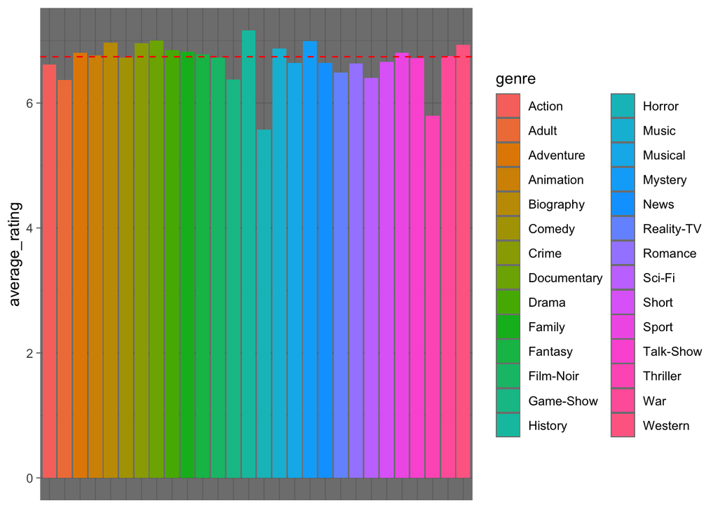

As we can see from the plot above, the average ratings have distributed quite evenly among the different genres. The next plot visualizes the average runtimes by genre.

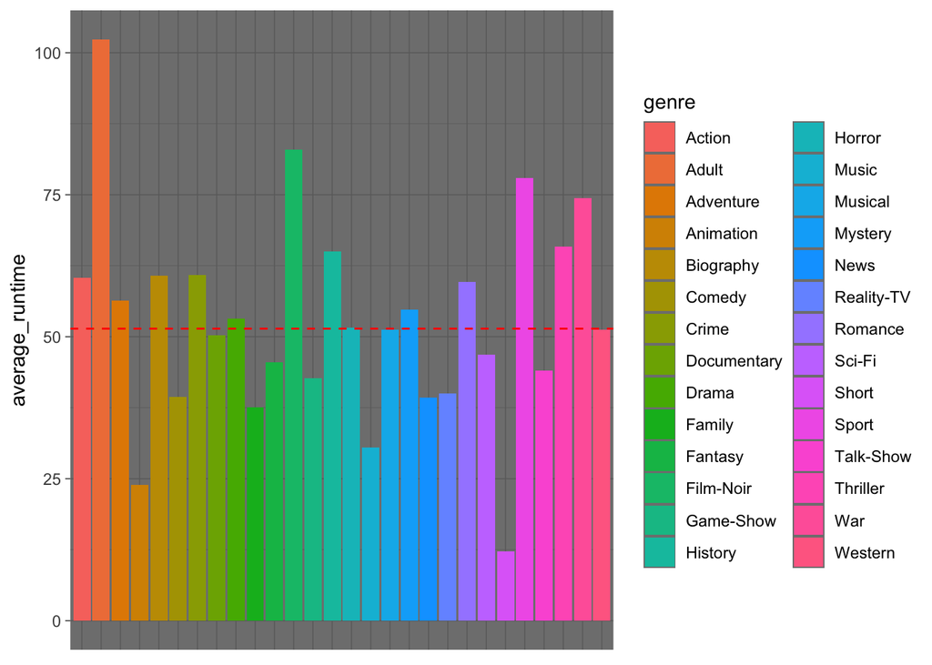

As we can see, the adult genre has clearly the highest average runtime of all the genres. The lowest ones, animation and short genres, have both runtimes below 25 minutes.

That is all for today. Next time, we will create a simple email spam filter with R. In the meanwhile, be sure to check out my other [projects](https://github.com/eenaveis/) too!